# Raport z wykresami 1

Joanna

Twoim celem jest odtworzenie tych wykresów, stworzonych przy użyciu danych Center of Legislative Effectiveness.

**WAŻNE: Przefiltruj dane, aby wyświetlić informacje tylko dla 115. Kongresu.**

## Wykres 1

**Wskazówki:**

- Dla osi y użyj zmiennej “all_pass”.
- Dla osi x użyj zmiennej “dwnom1”.
- Upewnij się, że przekodujesz dane dla zmiennej “female” i zmienisz jej nazwę na “Gender”, aby wygenerować poprawne etykiety dla legendy.
- Ustaw estetykę koloru w funkcji ggplot(), aby kolor kropek zmieniał się w zależności od płci (Gender).
- Upewnij się, że etykiety osi są poprawne.

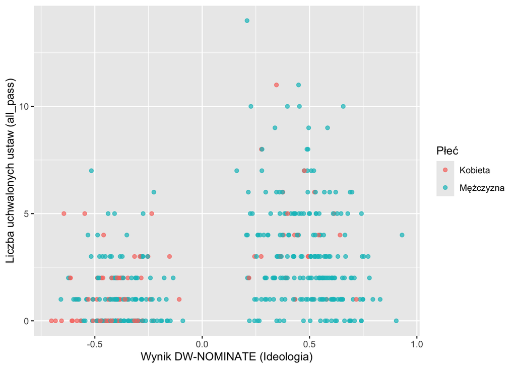

```r
# Najpierw filtrujemy dane dla 115. Kongresu i tworzymy czytelne etykiety (Gender i majority_status)
cel_115 <- cel %>%
  filter(congress == 115) %>%
  mutate(
    Gender = ifelse(female == 1, "Kobieta", "Mężczyzna"),
    majority_status = ifelse(majority == 1, "Większość", "Mniejszość")
  )

# Rysowanie Wykresu 1
ggplot(data = cel_115, aes(x = dwnom1, y = all_pass, color = Gender)) +
  geom_point(alpha = 0.7) +
  labs(
    x = "Wynik DW-NOMINATE (Ideologia)",
    y = "Liczba uchwalonych ustaw (all_pass)",
    color = "Płeć"
  )
```

## Wykres 2

**Wskazówki:**

- Dla osi x użyj zmiennej “votepct”.
- Dla osi y użyj zmiennej “all_pass”.
- Upewnij się, że przekodujesz dane dla zmiennej “female”, aby wygenerować poprawne etykiety dla legendy. Zmień nazwę tej kolumny na “Gender”. (mogłeś to już zrobić w poprzednim zadaniu)
- Upewnij się, że przekodujesz dane dla zmiennej “majority”, aby wygenerować poprawne etykiety dla wykresów podzielonych na panele (ang. *facetted figures*).
- Ustaw estetykę koloru w funkcji ggplot(), aby kolor kropek zmieniał się w zależności od płci (Gender).
- Użyj `scale_color_manual()`, aby ustawić kolory na zielony dla mężczyzn i pomarańczowy dla kobiet.
- Upewnij się, że etykiety osi są poprawne.

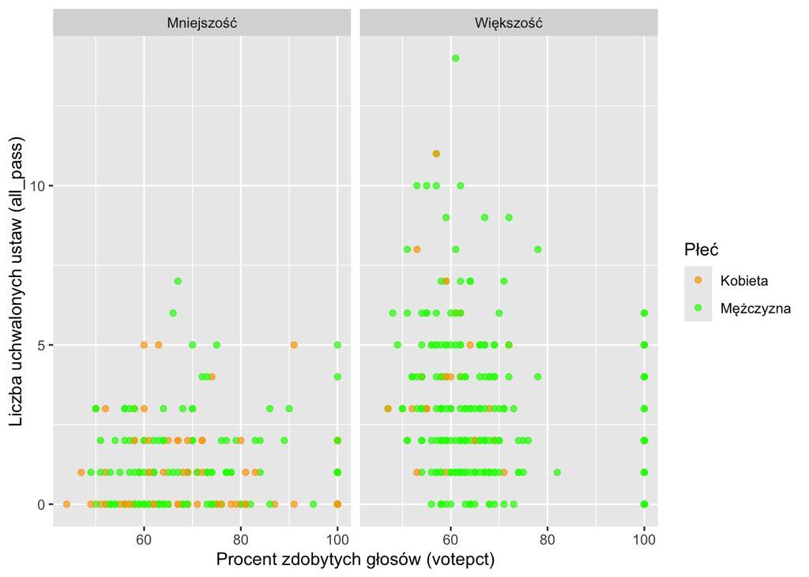

```r
# Używamy gotowego zbioru cel_115 z poprzedniego kroku.
# Funkcja facet_wrap() dzieli wykres na panele według statusu partii.
ggplot(data = cel_115, aes(x = votepct, y = all_pass, color = Gender)) +
  geom_point(alpha = 0.7) +
  facet_wrap(~ majority_status) +
  scale_color_manual(values = c("Mężczyzna" = "green", "Kobieta" = "orange")) +
  labs(
    x = "Procent zdobytych głosów (votepct)",
    y = "Liczba uchwalonych ustaw (all_pass)",
    color = "Płeć"
  )
```

## Wykres 3

**Wskazówki:**

- Dla osi y użyj zmiennej “les”.
- Upewnij się, że przekodujesz dane dla zmiennej “majority”, aby wygenerować poprawne etykiety. (mogłeś to już zrobić w poprzednim zadaniu)
- Upewnij się, że etykiety osi i tytuł wykresu są poprawne.

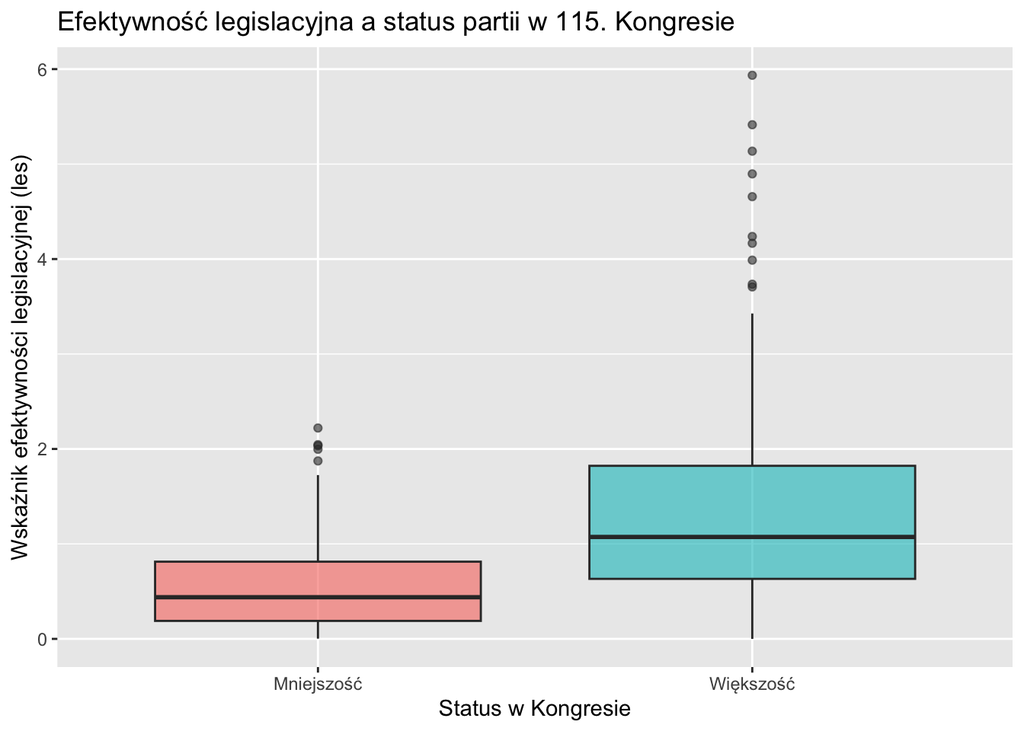

```r
# Rysujemy wykres pudełkowy (boxplot) dla wskaźnika LES w zależności od statusu większości
ggplot(data = cel_115, aes(x = majority_status, y = les, fill = majority_status)) +
  geom_boxplot(alpha = 0.6) +
  labs(
    x = "Status w Kongresie",
    y = "Wskaźnik efektywności legislacyjnej (les)",
    title = "Efektywność legislacyjna a status partii w 115. Kongresie"
  ) +
  theme(legend.position = "none") # Ukrywamy legendę, bo etykiety osi x wystarczą
```